Lesson 4 ========================================================

```r
knitr::opts_chunk$set(echo = T, fig.width = 7, fig.align = "center", out.width = "80%")
library(ggplot2)
library(dplyr, tidyr)
setwd("C:/Users/Christopher/Desktop/Nanodegree/P4-EDA/eda-course-materials/")

pfd <- read.csv("pseudo_facebook.tsv", sep = "\t")
```

### Scatterplots and Perceived Audience Size Notes:

### Scatterplots Notes:

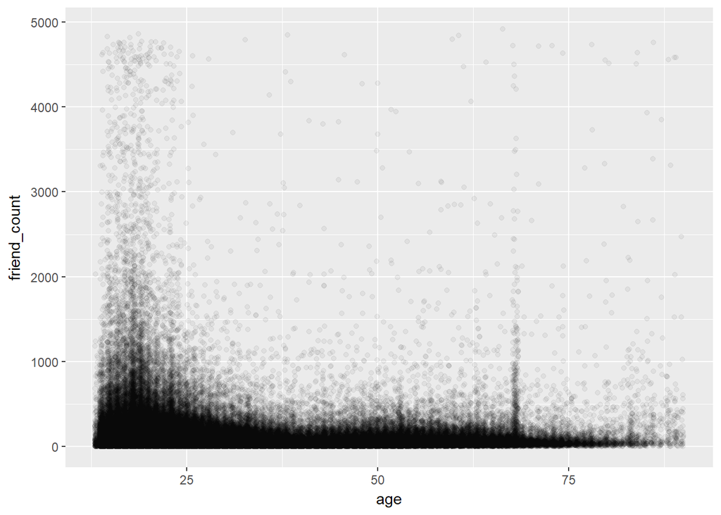

```r
ggplot(aes(x = age, y = friend_count), data = pfd) +
  geom_jitter(alpha=1/20) + xlim(c(13,90))
```

#### What are some things that you notice right away? Response:

### ggplot Syntax Notes:

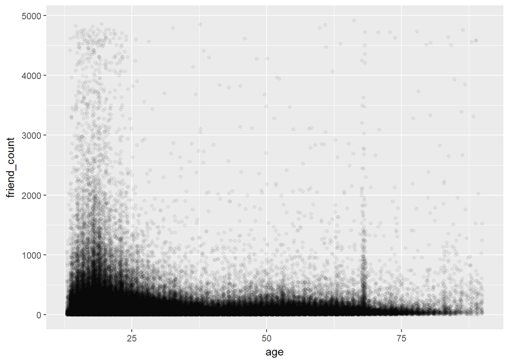

```r
ggplot(aes(x = age, y = friend_count), data = pfd) +
  geom_jitter(alpha=1/20) + xlim(c(13,90))
```

### Overplotting Notes:

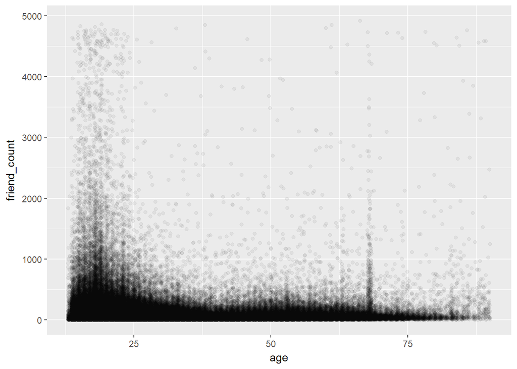

```r
ggplot(aes(x = age, y = friend_count), data = pfd) +
  geom_jitter(alpha=1/20) + xlim(c(13,90))
```

#### What do you notice in the plot? Response:

### Coord_trans() Notes:

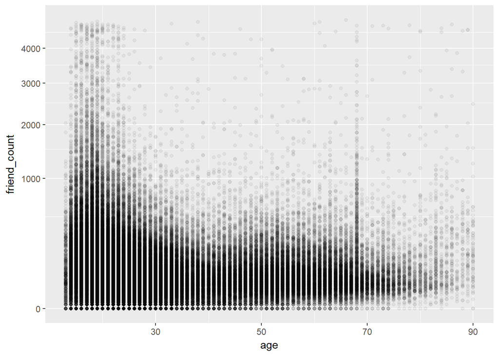

```r
ggplot(aes(x = age, y = friend_count), data = pfd) +
  geom_point(alpha=1/20) + xlim(c(13,90)) +
  coord_trans(y="sqrt")
```

#### Look up the documentation for coord_trans() and add a layer to the plot

that transforms friend_count using the square root function. Create your plot!

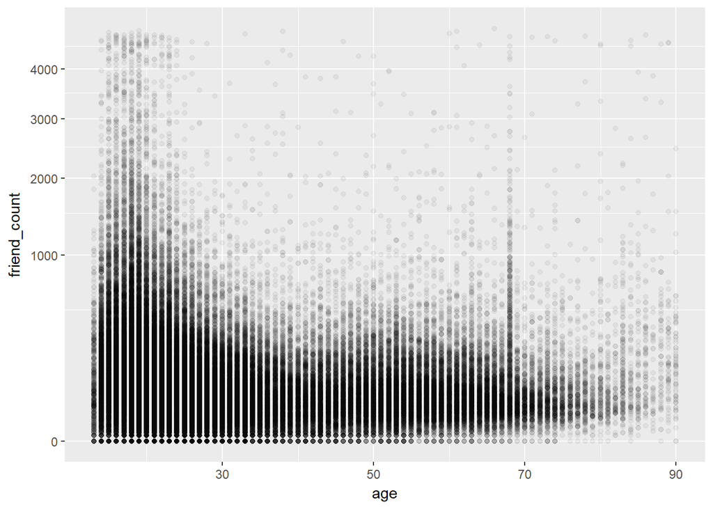

```r
ggplot(aes(x = age, y = friend_count), data = pfd) +
  geom_point(alpha=1/20) + xlim(c(13,90)) +
  coord_trans(y="sqrt")
```

#### What do you notice? Jitter doesn’t work because it “jitters” the data

points, inserting noise between points to spread them out a bit. For our zero-valued friend counts, this can lead to negative values, and the sqrt coord_trans then returns an error. If R were better-written, the error would point out that sqrt is being passed negative numbers, but it doesn’t. ***

### Alpha and Jitter Notes:

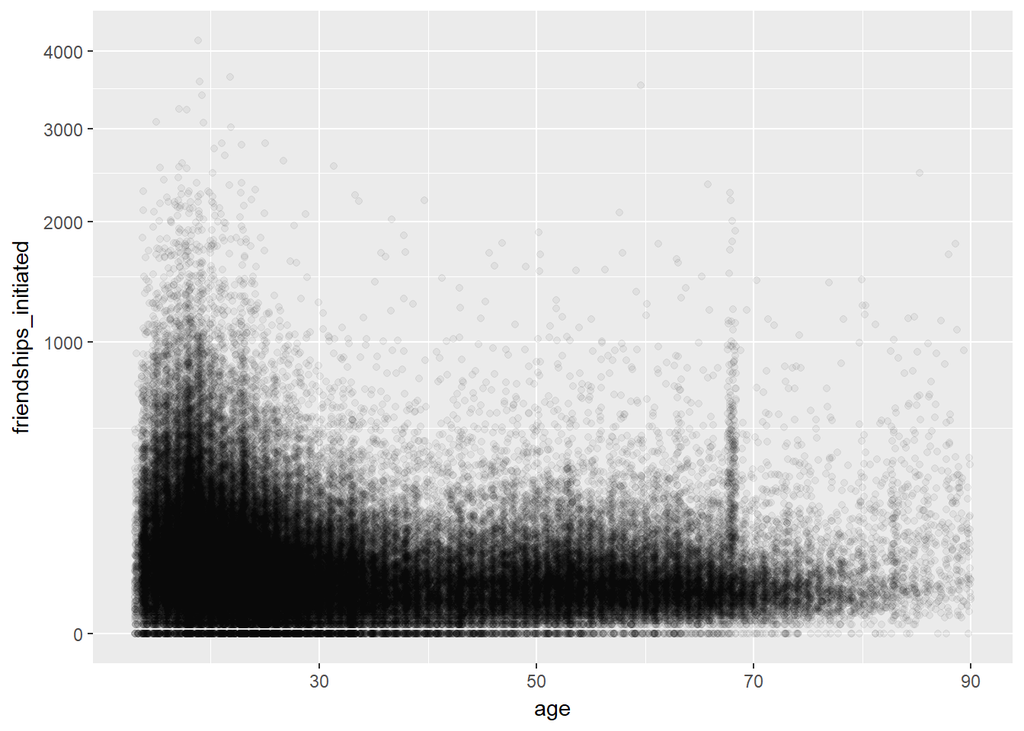

```r
ggplot(aes(x= age, y=friendships_initiated), data=pfd) +
  geom_point(alpha=1/20, position=position_jitter(h=0)) +
  xlim(c(13,90)) + coord_trans(y='sqrt')
```

### Overplotting and Domain Knowledge Notes:

### Conditional Means Notes:

```r
agegroups = group_by(pfd, age)
pfd.fc_by_age = summarize(agegroups,
                          friend_count_mean = mean(friend_count),
                          friend_count_median = median(friend_count),
                          n=n())
pfd.fc_by_age = arrange(pfd.fc_by_age, age)
```

```r
pfd.fc_by_age <- group_by(pfd, age) %>%
  summarize(friend_count_mean = mean(friend_count),
            friend_count_median = median(friend_count),
            n=n()) %>% arrange(age)
```

Create your plot!

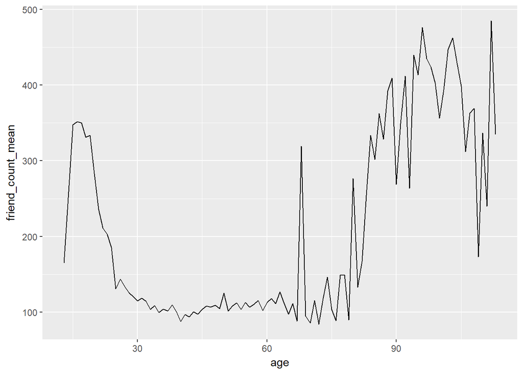

```r
ggplot(aes(x = age, y = friend_count_mean), data = pfd.fc_by_age) +
  geom_line()
```

### Overlaying Summaries with Raw Data Notes:

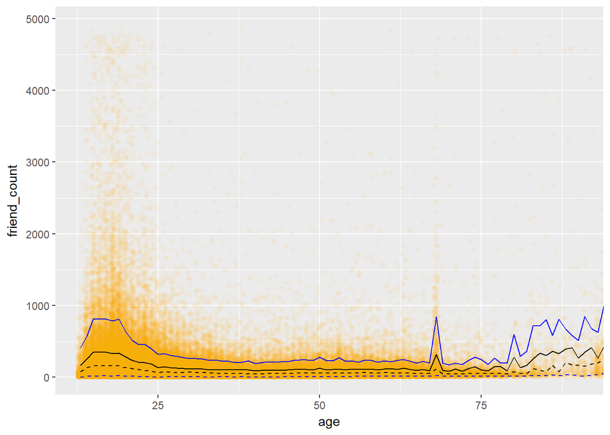

```r
ggplot(aes(x = age, y = friend_count), data = pfd) +
  geom_point(position = position_jitter(h=0),
             alpha=1/20,
             color='orange') +
  coord_cartesian(xlim = c(13, 90)) +
  geom_line(stat='summary', fun.y=mean) +
  geom_line(stat='summary', fun.y=median, linetype=2) +
  geom_line(stat="summary", fun.y=quantile,
            fun.args = list(probs = .9),
            color="blue" ) +
  geom_line(stat="summary", fun.y=quantile,
            fun.args = list(probs = .1), linetype=2, color="blue")
```

#### What are some of your observations of the plot? Response:

### Moira: Histogram Summary and Scatterplot See the Instructor Notes of this

video to download Moira’s paper on perceived audience size and to see the final plot.

Notes:

### Correlation Notes:

```r
with(pfd, cor.test(age, friend_count, method='pearson'))
```

```
##
##  Pearson's product-moment correlation
##
## data:  age and friend_count
## t = -8.6268, df = 99001, p-value < 2.2e-16
## alternative hypothesis: true correlation is not equal to 0
## 95 percent confidence interval:
##  -0.03363072 -0.02118189
## sample estimates:
##         cor
## -0.02740737
```

Look up the documentation for the cor.test function.

What’s the correlation between age and friend count? Round to three decimal places. Response:

### Correlation on Subsets Notes:

### Correlation Methods Notes: cor.test defaults to pearson’s ***

## Create Scatterplots Notes:

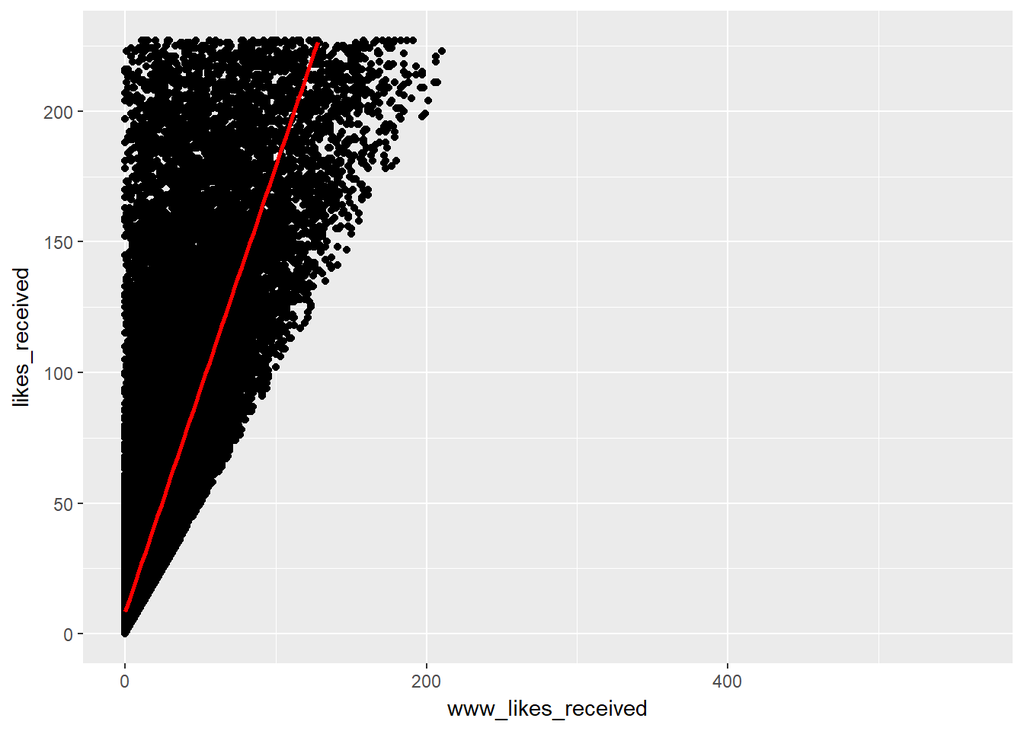

```r
ggplot(data=pfd, aes(x=www_likes_received, y=likes_received)) +
  geom_point() +
  xlim(0, quantile(pfd$likes_received, 0.95)) +
  ylim(0, quantile(pfd$www_likes_received, 0.95)) +
  geom_smooth(method = 'lm', color = 'red')
```

### Strong Correlations Notes:

```r
with(subset(pfd, age <= 70),
     cor.test(www_likes_received, likes_received))
```

```
##
##  Pearson's product-moment correlation
##
## data:  www_likes_received and likes_received
## t = 928.32, df = 91029, p-value < 2.2e-16
## alternative hypothesis: true correlation is not equal to 0
## 95 percent confidence interval:
##  0.9504075 0.9516488
## sample estimates:
##      cor
## 0.951032
```

What’s the correlation betwen the two variables? Include the top 5% of values for the variable in the calculation and round to 3 decimal places.

```r
with(pfd, cor.test(www_likes_received, likes_received))
```

```
##
##  Pearson's product-moment correlation
##
## data:  www_likes_received and likes_received
## t = 937.1, df = 99001, p-value < 2.2e-16
## alternative hypothesis: true correlation is not equal to 0
## 95 percent confidence interval:
##  0.9473553 0.9486176
## sample estimates:
##       cor
## 0.9479902
```

Response:

### Moira on Correlation Notes:

### More Caution with Correlation Notes:

```r
library(alr3)
data(Mitchell)
```

Create your plot!

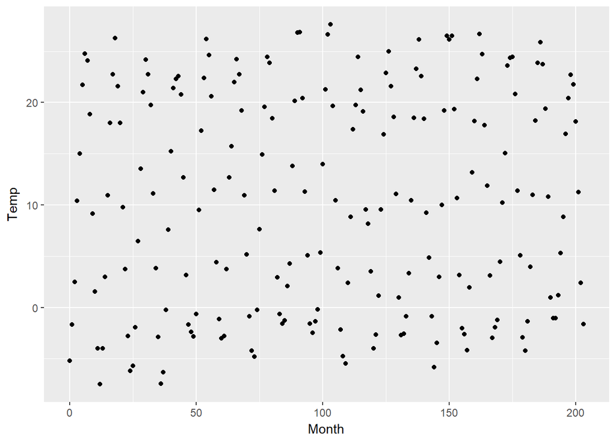

```r
ggplot(data=Mitchell, aes(x=Month, y=Temp)) + geom_point()
```

### Noisy Scatterplots a. Take a guess for the correlation coefficient for the

scatterplot.

2. What is the actual correlation of the two variables? (Round to the thousandths place)

```r
cor.test(Mitchell$Month, Mitchell$Temp)
```

```
##
##  Pearson's product-moment correlation
##
## data:  Mitchell$Month and Mitchell$Temp
## t = 0.81816, df = 202, p-value = 0.4142
## alternative hypothesis: true correlation is not equal to 0
## 95 percent confidence interval:
##  -0.08053637  0.19331562
## sample estimates:
##        cor
## 0.05747063
```

### Making Sense of Data Notes:

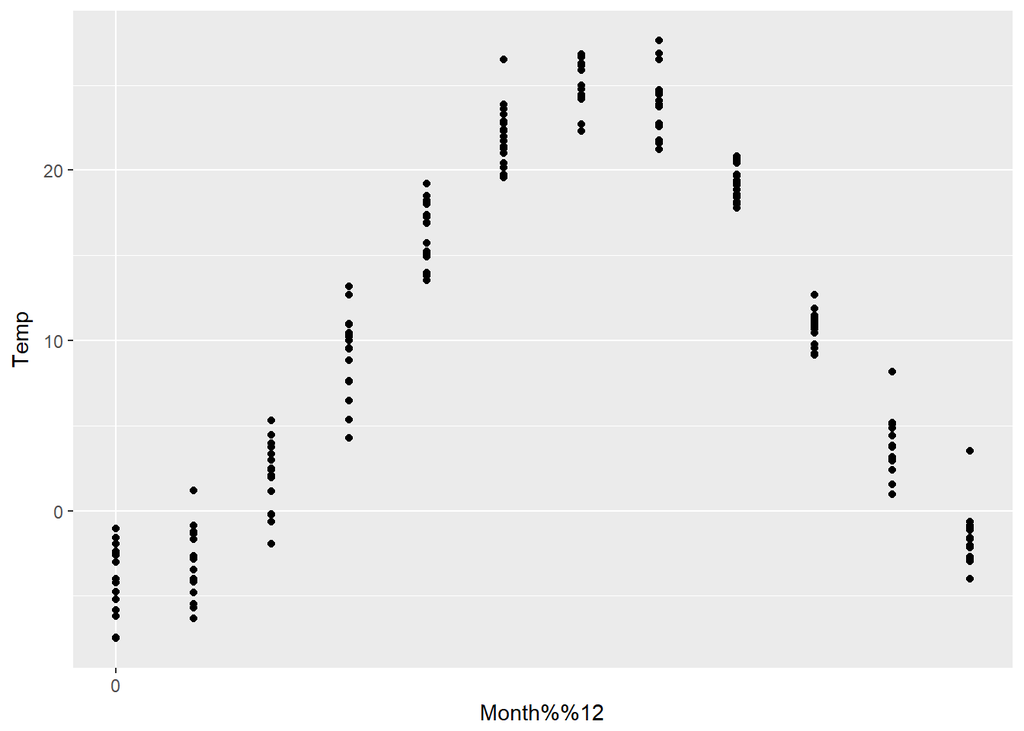

```r
ggplot(data=Mitchell, aes(x=Month%%12, y=Temp)) + geom_point() +
  scale_x_continuous(breaks=seq(0,203,12))
```

```r
Mitchell$stdmonth <- Mitchell$Month%%12
by_month <- group_by(Mitchell, stdmonth)
mthlymeans <- by_month %>% summarize(mean_temp = mean(Temp))
```

### A New Perspective

What do you notice? Response:

Watch the solution video and check out the Instructor Notes! Notes:

### Understanding Noise: Age to Age Months Notes:

```r
pfd$age_with_months <- pfd$age + (1-pfd$dob_month/12)
head(pfd$age_with_months,10)
```

```
##  [1] 14.08333 14.08333 14.08333 14.00000 14.00000 14.00000 13.91667
##  [8] 13.91667 13.91667 13.83333
```

### Age with Months Means

```r
pfd.fc_by_age_months <-  pfd %>%
  group_by(age_with_months) %>%
  summarize(friend_count_mean = mean(friend_count),
            friend_count_median= median(friend_count),
            n = n()) %>%
  arrange(age_with_months)
```

Programming Assignment

### Noise in Conditional Means

```r
library(gridExtra)
```

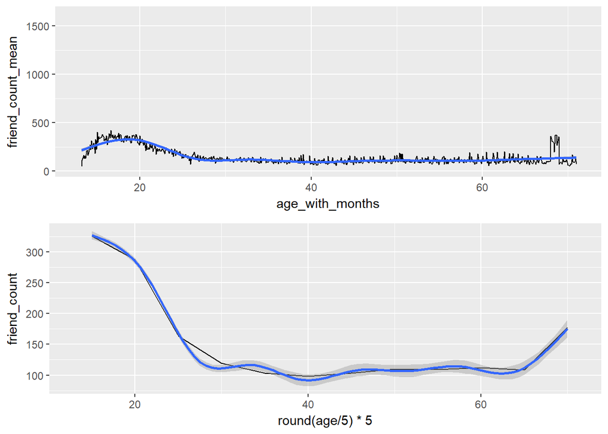

```r
p1 = ggplot(data=pfd.fc_by_age_months, aes(x=age_with_months, y=friend_count_mean)) +
  geom_line() +
  geom_smooth() +
  xlim(c(13,71))

p2 = ggplot(data=pfd, aes(x=round(age/5)*5, y=friend_count)) +
  geom_line(stat="summary", fun.y=mean) +
  geom_smooth() +
  xlim(c(13,71))
grid.arrange(p1,p2)
```

### Smoothing Conditional Means Notes:

### Which Plot to Choose? Notes:

### Analyzing Two Variables Reflection:

Click **KnitHTML** to see all of your hard work and to have an html page of this lesson, your answers, and your notes!